# Differential Gene Expression Analysis — Cisplatin Resistance in Ovarian Cancer

Member 2 — DEGs & Biology

2026-09-08

# 1 Overview

This report presents the differential gene expression (DGE) analysis of two independent **cisplatin-resistant vs. sensitive ovarian cancer** RNA-seq datasets. The goal is to identify differentially expressed genes (DEGs) associated with platinum resistance and discover shared molecular signatures.

[output not shown]

**DEG Thresholds:** FDR < 0.05 and |log₂FC| > 1

# 2 Dataset 1: GSE303889 — SKOV-3

## 2.1 Study Context

KDM5-mediated cisplatin resistance in ovarian cancer (Yonsei University, 2025). SKOV-3 parental (sensitive) vs. SKOV-3 CDDP (cisplatin-resistant) cells.

## 2.2 DESeq2 Results Summary

| Metric | Count |
| --- | --- |
| Total genes tested | 22372 |
| Significant DEGs | 5212 |
| Up-regulated | 2983 |
| Down-regulated | 2229 |

## 2.3 Volcano Plot

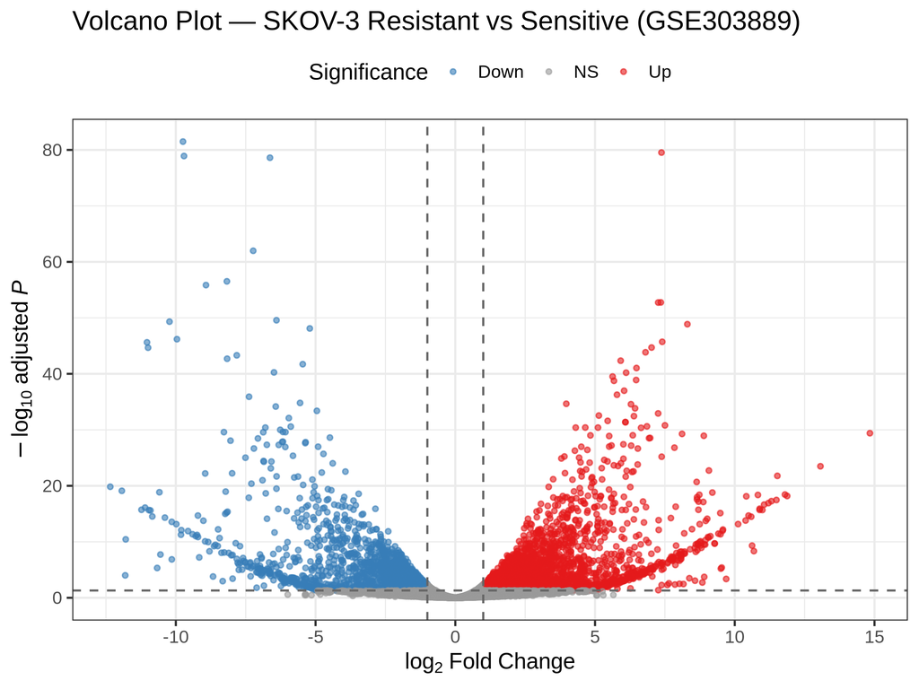

## 2.4 Top DEG Heatmap

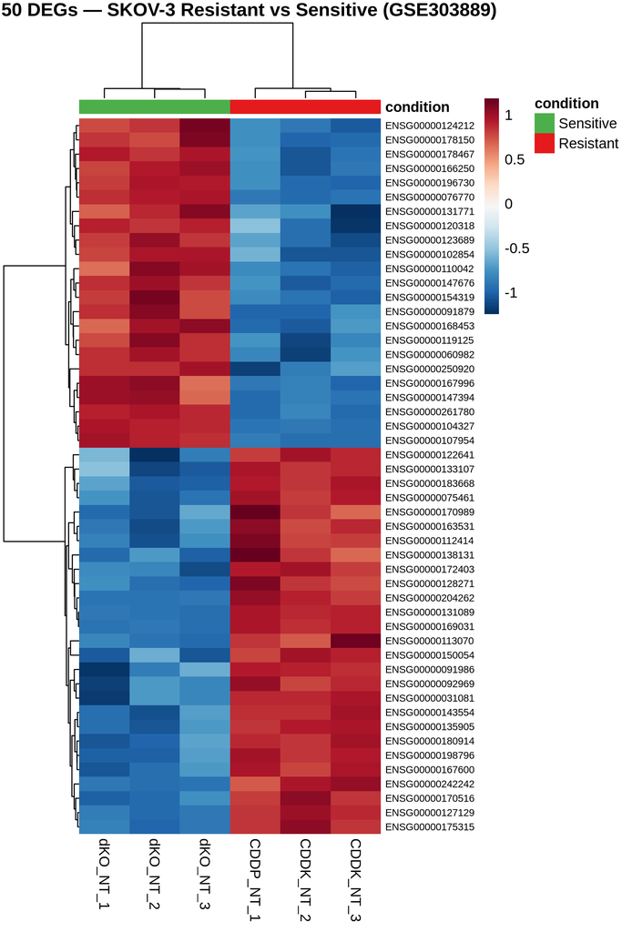

## 2.5 MA Plot

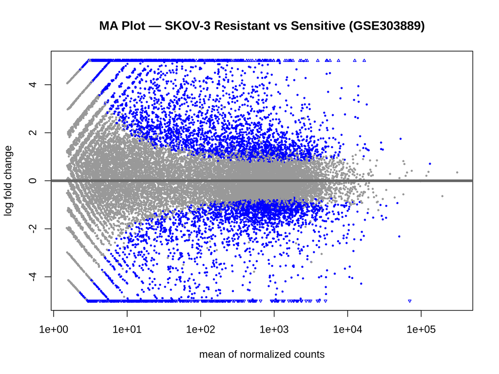

## 2.6 Top 20 Up-regulated Genes

| Gene ID | Mean Expr | log₂FC | Adj. P-value |
| --- | --- | --- | --- |
| ENSG00000204262 | 2672 | 7.378 | 2.96e-80 |
| ENSG00000198796 | 910 | 7.354 | 1.74e-53 |
| ENSG00000127129 | 640 | 7.261 | 1.83e-53 |
| ENSG00000183668 | 740 | 8.304 | 1.35e-49 |
| ENSG00000075461 | 509 | 7.404 | 1.90e-46 |
| ENSG00000242242 | 632 | 7.023 | 2.00e-45 |
| ENSG00000163531 | 1116 | 6.806 | 1.41e-44 |
| ENSG00000143554 | 767 | 5.918 | 4.49e-43 |
| ENSG00000131089 | 302 | 6.484 | 9.14e-42 |
| ENSG00000092969 | 882 | 6.113 | 6.23e-41 |
| ENSG00000180914 | 1590 | 5.628 | 3.05e-40 |
| ENSG00000091986 | 2346 | 6.471 | 1.26e-39 |
| ENSG00000112414 | 2813 | 5.677 | 1.74e-39 |
| ENSG00000128271 | 604 | 6.042 | 1.03e-37 |
| ENSG00000167600 | 360 | 5.786 | 5.44e-37 |
| ENSG00000169031 | 719 | 3.971 | 2.22e-35 |
| ENSG00000170516 | 325 | 6.286 | 2.68e-35 |
| ENSG00000122641 | 690 | 6.432 | 1.43e-34 |
| ENSG00000133107 | 360 | 7.259 | 1.17e-33 |
| ENSG00000113070 | 1168 | 5.137 | 2.83e-33 |

## 2.7 Top 20 Down-regulated Genes

| Gene ID | Mean Expr | log₂FC | Adj. P-value |
| --- | --- | --- | --- |
| ENSG00000104327 | 2107 | -9.745 | 3.28e-82 |
| ENSG00000261780 | 2063 | -9.709 | 1.23e-79 |
| ENSG00000107954 | 1703 | -6.632 | 2.50e-79 |
| ENSG00000147676 | 1852 | -7.232 | 1.05e-62 |
| ENSG00000166250 | 1085 | -8.173 | 3.00e-57 |
| ENSG00000119125 | 2985 | -8.922 | 1.40e-56 |
| ENSG00000060982 | 1715 | -6.399 | 2.66e-50 |
| ENSG00000250920 | 1363 | -10.227 | 4.76e-50 |
| ENSG00000196730 | 1278 | -5.207 | 7.77e-49 |
| ENSG00000131771 | 4995 | -9.960 | 6.43e-47 |
| ENSG00000091879 | 2368 | -11.032 | 2.37e-46 |
| ENSG00000123689 | 2011 | -10.994 | 2.13e-45 |
| ENSG00000178467 | 481 | -7.820 | 4.90e-44 |
| ENSG00000124212 | 947 | -8.165 | 2.00e-43 |
| ENSG00000167996 | 69899 | -5.459 | 1.88e-42 |
| ENSG00000154319 | 923 | -6.488 | 5.49e-41 |
| ENSG00000120318 | 469 | -7.381 | 1.23e-36 |
| ENSG00000147394 | 550 | -5.555 | 1.57e-35 |
| ENSG00000168453 | 477 | -6.425 | 6.90e-35 |
| ENSG00000110042 | 4164 | -4.953 | 4.10e-34 |

# 3 Dataset 2: GSE283381 — OVCAR5

## 3.1 Study Context

Metabolic dependency on de novo pyrimidine synthesis in platinum-resistant ovarian cancer (Northwestern University, 2024). OVCAR5 cisplatin-sensitive (Cis-S) vs. cisplatin-resistant (Cis-R) cells.

## 3.2 DESeq2 Results Summary

| Metric | Count |
| --- | --- |
| Total genes tested | 20959 |
| Significant DEGs | 2572 |
| Up-regulated | 912 |
| Down-regulated | 1660 |

## 3.3 Volcano Plot

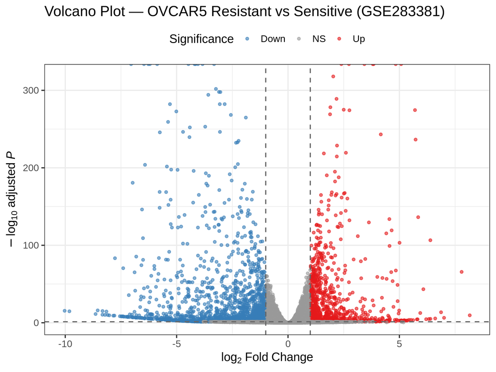

## 3.4 Top DEG Heatmap

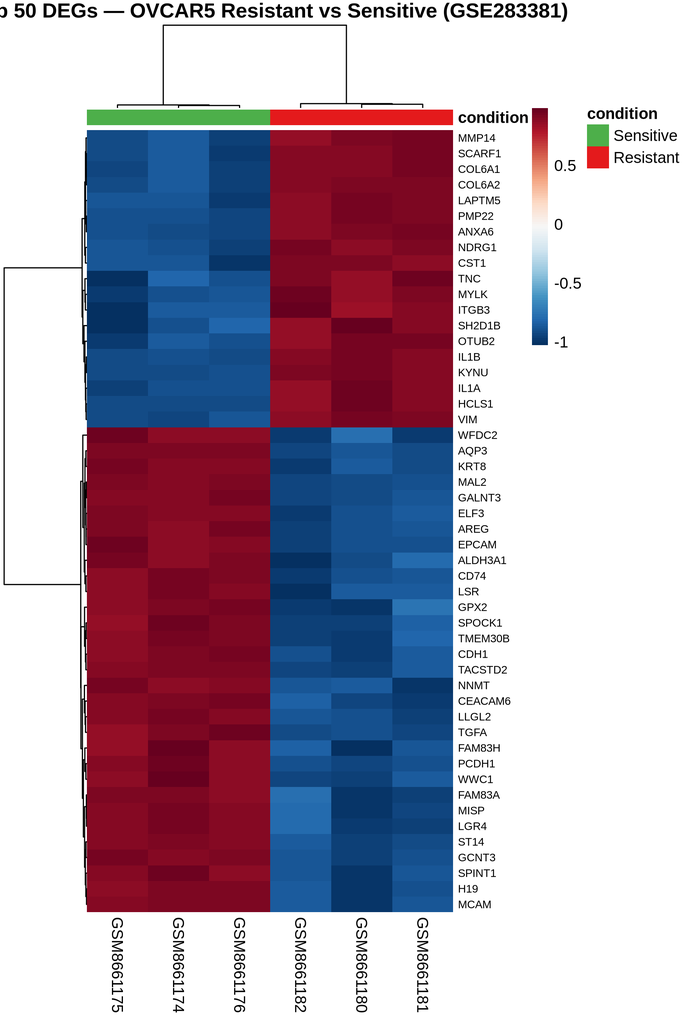

## 3.5 MA Plot

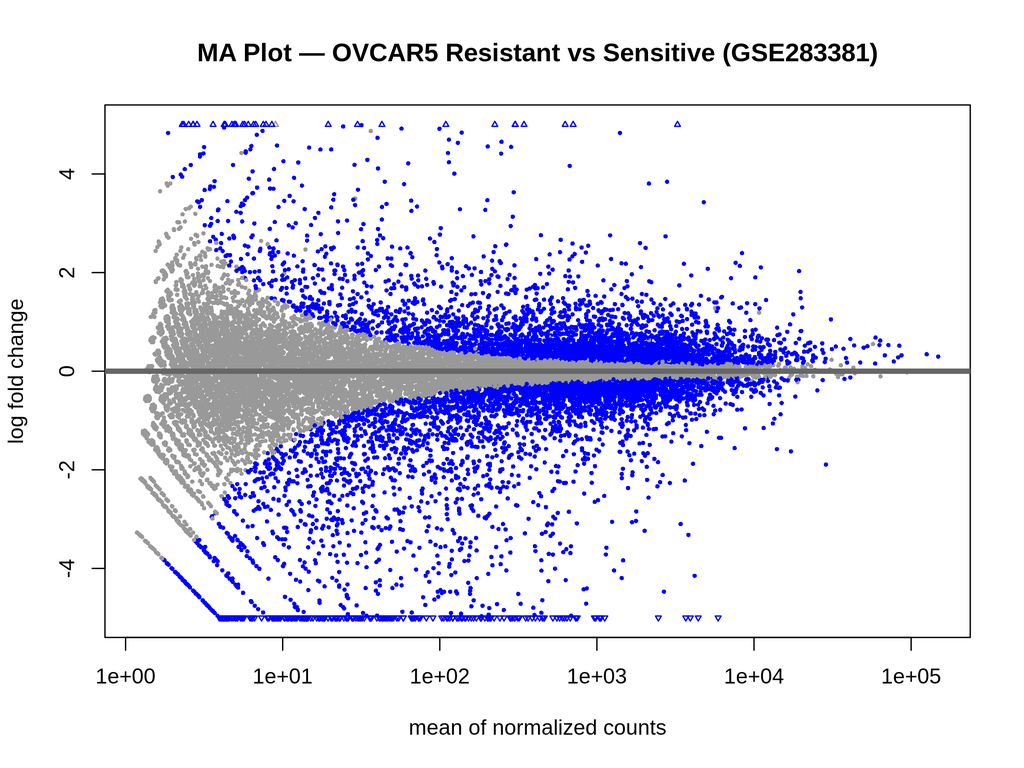

## 3.6 Top 20 Up-regulated Genes

| Gene | Mean Expr | log₂FC | Adj. P-value |
| --- | --- | --- | --- |
| IL1A | 4790 | 3.428 | 0.00e+00 |
| IL1B | 3258 | 5.078 | 0.00e+00 |
| KYNU | 2797 | 3.842 | 0.00e+00 |
| LAPTM5 | 2144 | 3.805 | 0.00e+00 |
| MMP14 | 8392 | 2.394 | 0.00e+00 |
| MYLK | 1400 | 4.833 | 0.00e+00 |
| SCARF1 | 2736 | 2.735 | 0.00e+00 |
| COL6A1 | 19380 | 2.030 | 1.22e-318 |
| NDRG1 | 3578 | 2.178 | 1.10e-289 |
| COL6A2 | 10204 | 1.901 | 6.70e-279 |
| OTUB2 | 2041 | 2.500 | 1.05e-275 |
| CST1 | 706 | 5.699 | 3.16e-275 |
| PMP22 | 1215 | 2.756 | 5.68e-275 |
| ANXA6 | 7144 | 1.887 | 8.51e-270 |
| SH2D1B | 672 | 4.165 | 7.87e-244 |
| HCLS1 | 628 | 5.727 | 3.75e-237 |
| TNC | 7639 | 2.199 | 2.04e-229 |
| ITGB3 | 1882 | 2.598 | 4.10e-220 |
| VIM | 19791 | 1.608 | 2.86e-219 |
| PRDM8 | 1433 | 2.190 | 2.47e-215 |

## 3.7 Top 20 Down-regulated Genes

| Gene | Mean Expr | log₂FC | Adj. P-value |
| --- | --- | --- | --- |
| AREG | 1469 | -3.837 | 0.00e+00 |
| CD74 | 3825 | -3.319 | 0.00e+00 |
| CDH1 | 2462 | -7.045 | 0.00e+00 |
| CEACAM6 | 4416 | -6.201 | 0.00e+00 |
| ELF3 | 1439 | -4.195 | 0.00e+00 |
| EPCAM | 4191 | -4.150 | 0.00e+00 |
| H19 | 1285 | -4.042 | 0.00e+00 |
| MAL2 | 3931 | -5.874 | 0.00e+00 |
| MCAM | 2673 | -4.471 | 0.00e+00 |
| ST14 | 5910 | -6.274 | 0.00e+00 |
| TACSTD2 | 3678 | -6.466 | 0.00e+00 |
| SPOCK1 | 2013 | -3.237 | 1.53e-302 |
| FAM83H | 3412 | -3.100 | 1.20e-298 |
| SPINT1 | 1774 | -3.037 | 1.73e-298 |
| LLGL2 | 1150 | -3.579 | 6.31e-295 |
| TGFA | 1782 | -2.844 | 6.18e-283 |
| ALDH3A1 | 1672 | -3.063 | 6.86e-283 |
| NNMT | 1122 | -5.300 | 6.86e-283 |
| AQP3 | 964 | -5.014 | 1.77e-273 |
| PCDH1 | 2129 | -2.565 | 5.58e-269 |

# 4 Cross-Dataset Comparison

## 4.1 Overlapping DEGs

| Metric | Count |
| --- | --- |
| Shared up-regulated | 198 |
| Shared down-regulated | 220 |
| Total shared DEGs | 913 |

## 4.2 Venn Diagram

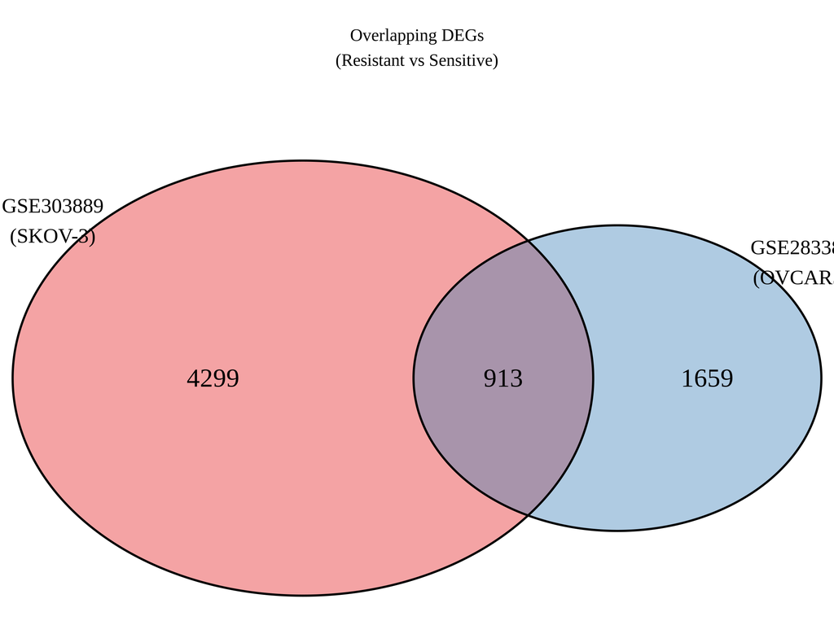

## 4.3 log₂FC Correlation

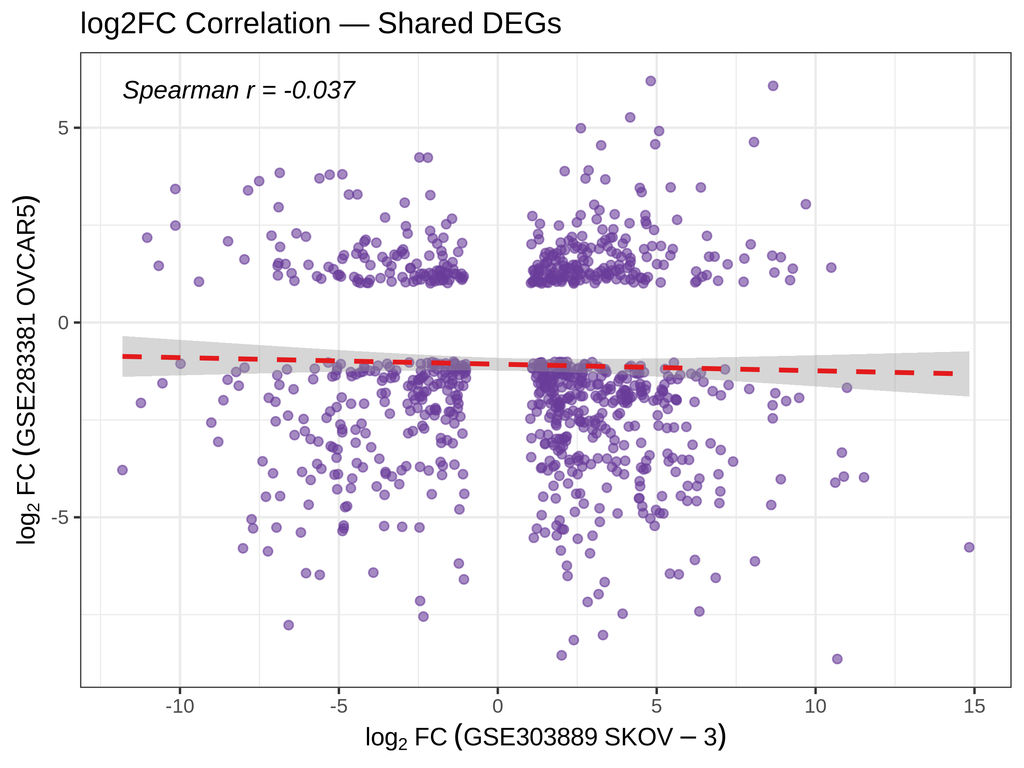

## 4.4 Shared Up-regulated Genes (Top 30)

| Gene | Dir | log₂FC (SKOV-3) | Padj (SKOV-3) | log₂FC (OVCAR5) | Padj (OVCAR5) |
| --- | --- | --- | --- | --- | --- |
| INHBA | Up | 6.432 | 1.43e-34 | 1.174 | 2.81e-63 |
| HBEGF | Up | 5.137 | 2.83e-33 | 1.966 | 4.27e-169 |
| DOCK10 | Up | 4.651 | 3.89e-31 | 2.600 | 3.20e-02 |
| SELENOM | Up | 6.648 | 4.37e-31 | 1.690 | 3.08e-80 |
| ANXA6 | Up | 5.506 | 1.28e-29 | 1.887 | 8.51e-270 |
| CCN2 | Up | 6.933 | 3.14e-29 | 1.072 | 5.77e-56 |
| REEP2 | Up | 4.279 | 5.34e-27 | 1.030 | 1.45e-04 |
| KCNMA1 | Up | 4.470 | 2.29e-23 | 3.456 | 8.86e-06 |
| CD82 | Up | 4.542 | 3.29e-23 | 1.140 | 1.32e-80 |
| GLIPR2 | Up | 3.502 | 6.62e-22 | 1.222 | 3.31e-15 |
| SRGN | Up | 8.637 | 2.04e-21 | 1.717 | 3.08e-42 |
| CD274 | Up | 6.262 | 1.66e-20 | 1.066 | 2.81e-23 |
| PTHLH | Up | 4.854 | 1.77e-20 | 1.962 | 8.23e-13 |
| COL13A1 | Up | 9.198 | 1.60e-19 | 1.087 | 1.72e-79 |
| SERPINE1 | Up | 4.484 | 1.94e-19 | 1.153 | 4.39e-117 |
| ARID5B | Up | 3.998 | 1.06e-18 | 1.098 | 8.47e-09 |
| APOBEC3F | Up | 4.175 | 2.34e-18 | 1.106 | 1.37e-07 |
| TNS1 | Up | 8.705 | 6.73e-18 | 1.283 | 1.72e-32 |
| AOX1 | Up | 6.215 | 1.81e-17 | 1.032 | 3.82e-06 |
| ADAMTS6 | Up | 4.149 | 2.55e-17 | 1.462 | 6.92e-13 |
| MIR4280HG | Up | 6.823 | 6.34e-17 | 1.692 | 6.39e-05 |
| APLN | Up | 4.332 | 1.04e-16 | 1.282 | 4.45e-07 |
| KCNH3 | Up | 3.815 | 1.19e-15 | 1.479 | 1.13e-09 |
| GALNT6 | Up | 10.494 | 2.06e-15 | 1.410 | 4.06e-104 |
| GPSM3 | Up | 3.393 | 6.79e-15 | 1.246 | 7.28e-31 |
| GRK5 | Up | 3.742 | 7.12e-15 | 1.768 | 6.09e-71 |
| DISP2 | Up | 3.861 | 1.58e-13 | 1.221 | 6.23e-30 |
| APOBEC3B | Up | 4.689 | 3.76e-13 | 1.683 | 2.28e-50 |
| LINC00460 | Up | 4.175 | 3.92e-13 | 1.655 | 1.34e-37 |
| PRICKLE2 | Up | 3.416 | 5.27e-13 | 1.172 | 1.95e-06 |

## 4.5 Shared Down-regulated Genes (Top 30)

| Gene | Dir | log₂FC (SKOV-3) | Padj (SKOV-3) | log₂FC (OVCAR5) | Padj (OVCAR5) |
| --- | --- | --- | --- | --- | --- |
| NEURL1 | Down | -6.632 | 2.50e-79 | -1.203 | 1.60e-02 |
| MAL2 | Down | -7.232 | 1.05e-62 | -5.874 | 0.00e+00 |
| DAPK1 | Down | -5.207 | 7.77e-49 | -1.386 | 1.17e-49 |
| HR | Down | -6.425 | 6.90e-35 | -1.714 | 7.11e-30 |
| DTX4 | Down | -4.953 | 4.10e-34 | -2.617 | 1.96e-192 |
| MSLN | Down | -5.887 | 2.64e-31 | -4.042 | 1.81e-87 |
| CASC19 | Down | -6.872 | 2.70e-30 | -1.601 | 4.02e-35 |
| MEST | Down | -7.207 | 2.16e-27 | -1.934 | 5.13e-76 |
| C6orf223 | Down | -5.808 | 4.31e-26 | -1.456 | 2.21e-08 |
| DMBT1 | Down | -6.580 | 4.67e-25 | -7.769 | 5.17e-84 |
| INAVA | Down | -6.395 | 2.07e-22 | -2.890 | 4.63e-60 |
| DSCAML1 | Down | -7.296 | 4.13e-21 | -4.473 | 3.85e-40 |
| ESRP2 | Down | -4.436 | 6.22e-20 | -3.609 | 8.70e-178 |
| PLEKHA6 | Down | -5.107 | 1.63e-18 | -1.358 | 7.75e-43 |
| PTPRR | Down | -4.896 | 3.67e-18 | -2.741 | 5.33e-19 |
| MISP | Down | -3.563 | 2.98e-17 | -4.425 | 2.67e-240 |
| SYBU | Down | -5.273 | 3.17e-17 | -2.282 | 7.73e-46 |
| C1orf116 | Down | -4.742 | 1.13e-16 | -4.716 | 6.11e-103 |
| FOXQ1 | Down | -11.229 | 1.91e-16 | -2.065 | 5.17e-111 |
| DTX1 | Down | -8.150 | 4.29e-16 | -1.623 | 3.37e-02 |
| GOLT1A | Down | -4.580 | 5.11e-16 | -4.005 | 6.22e-06 |
| FAM83A | Down | -5.647 | 6.41e-16 | -3.056 | 4.51e-247 |
| RASSF6 | Down | -8.233 | 1.01e-15 | -1.269 | 2.87e-06 |
| AVPI1 | Down | -4.243 | 6.54e-15 | -1.261 | 4.76e-23 |
| DHRS2 | Down | -4.285 | 1.66e-14 | -2.596 | 7.78e-47 |
| LINC00431 | Down | -9.015 | 1.71e-14 | -2.570 | 4.12e-02 |
| BST2 | Down | -4.616 | 1.76e-14 | -2.085 | 2.09e-143 |
| DENND2D | Down | -5.602 | 3.47e-14 | -6.478 | 1.47e-33 |
| TNFSF12 | Down | -9.983 | 7.07e-14 | -1.057 | 1.20e-03 |
| BISPR | Down | -4.597 | 9.24e-14 | -1.377 | 8.40e-05 |

# 5 Functional Enrichment

## 5.1 Shared DEGs — GO Enrichment

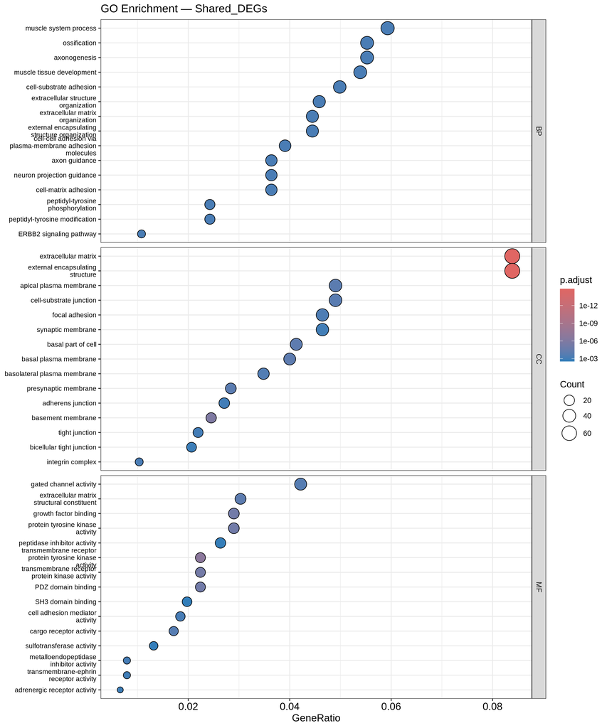

## 5.2 Shared DEGs — KEGG Pathways

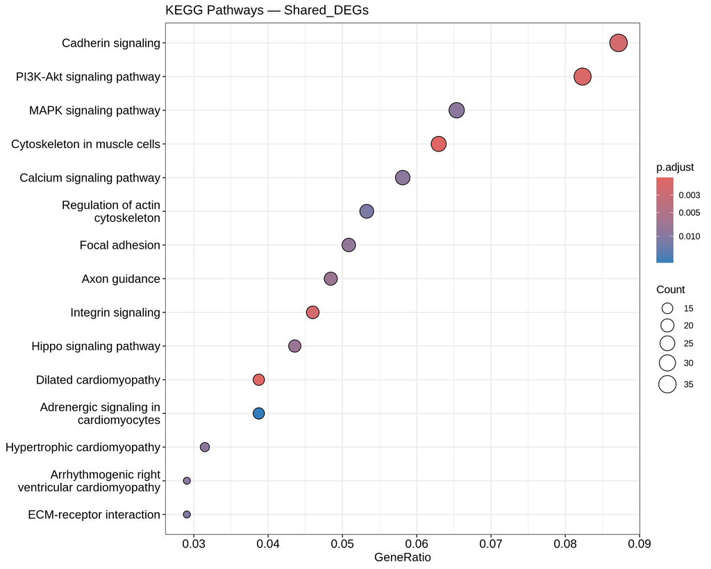

## 5.3 Dataset 1 (SKOV-3) — GO Enrichment

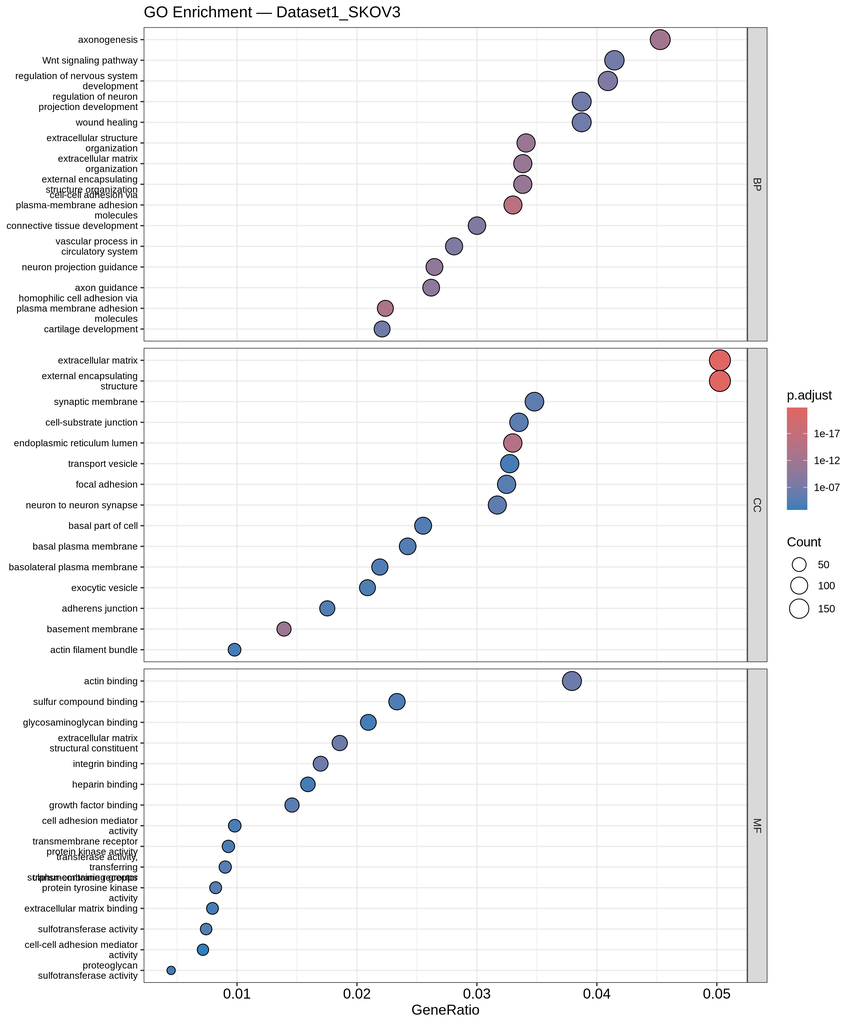

## 5.4 Dataset 1 (SKOV-3) — KEGG Pathways

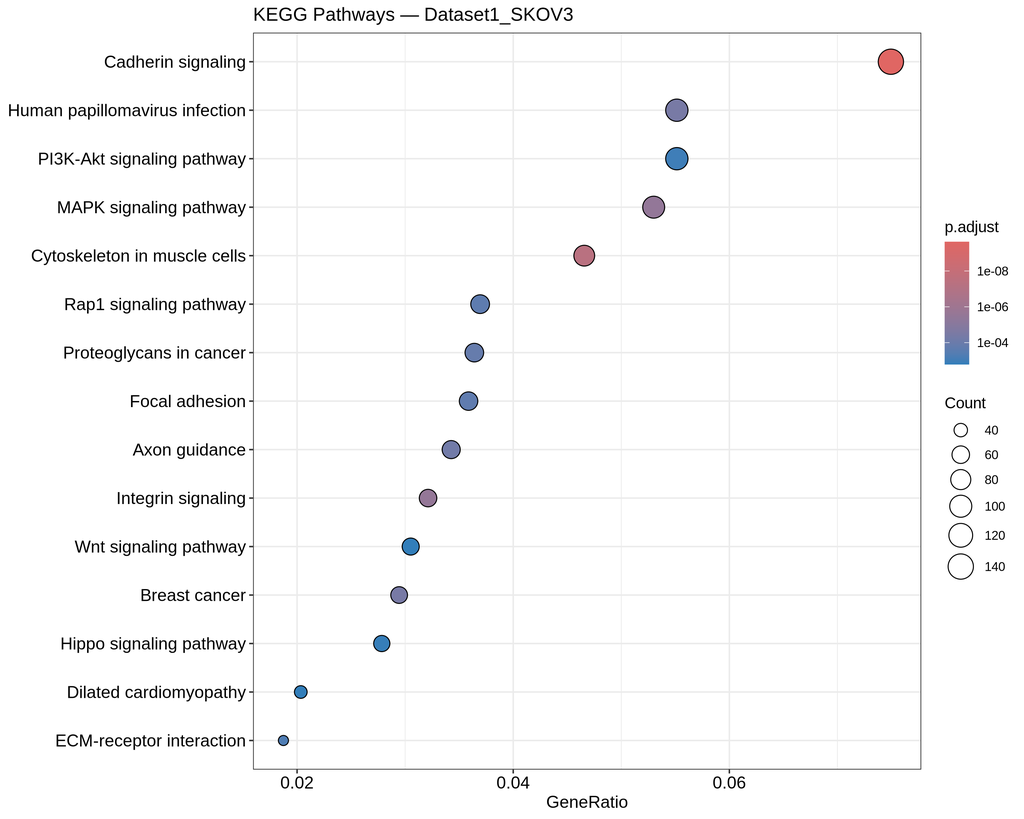

## 5.5 Dataset 2 (OVCAR5) — GO Enrichment

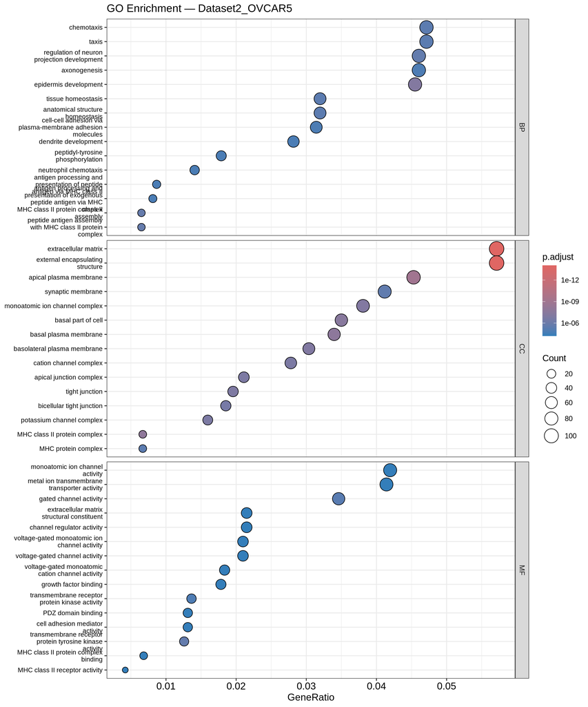

## 5.6 Dataset 2 (OVCAR5) — KEGG Pathways

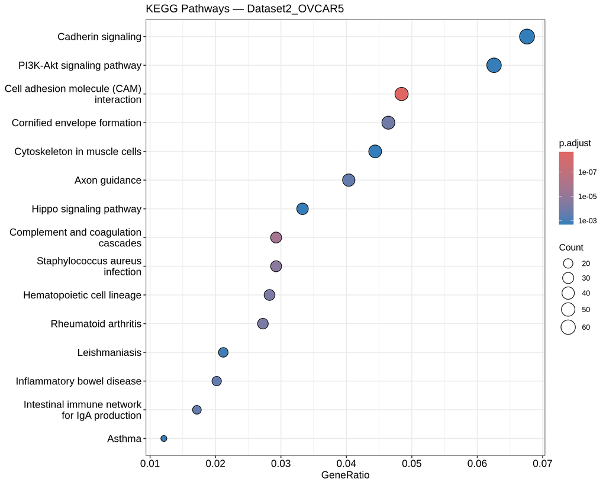

# 6 Machine Learning & Biomarker Discovery

## 6.1 Overview

The **418 consistently regulated shared DEGs** (198 up + 220 down; mixed-direction genes excluded) were used as candidate features to build classification models distinguishing **Resistant** from **Sensitive** samples across both datasets (12 samples total).

- **Feature matrix:** `results/ml/expression_matrix.csv` (12 samples × genes, `log2(CPM+1)`)
- **Models:** Logistic Regression (L1, glmnet), Random Forest (ranger), SVM (radial, e1071)
- **Nested feature selection:** within every training fold, top-K genes by |t-statistic| (K ∈ {10, 20, 30}) — no test information used
- **Validation:**
  1. **LOOCV** across all 12 samples
  2. **Leave-one-dataset-out** external validation — train on one cell line, predict the other

> Because n = 12 (6 per cell line), these results are **exploratory biomarker discovery**, not clinical validation (proposal §7).

## 6.2 Model Performance Summary (top-K = 20)

| Validation | Model | Accuracy | Precision | Recall | F1 | ROC-AUC |
| --- | --- | --- | --- | --- | --- | --- |
| LOOCV | LogisticRegression | 1.000 | 1.000 | 1 | 1.000 | 1.000 |
| LOOCV | RandomForest | 0.917 | 0.857 | 1 | 0.923 | 1.000 |
| LOOCV | SVM | 1.000 | 1.000 | 1 | 1.000 | 1.000 |
| External | LogisticRegression | 0.500 | 0.500 | 1 | 0.667 | 0.639 |
| External | RandomForest | 0.500 | NA | 0 | NA | 0.500 |
| External | SVM | 0.500 | 0.500 | 1 | 0.667 | 0.569 |

**All model / K combinations**

| validation | model | K | n | Accuracy | Precision | Recall | F1 | ROC_AUC |
| --- | --- | --- | --- | --- | --- | --- | --- | --- |
| LOOCV | LogisticRegression | 10 | 12 | 1.000 | 1.000 | 1.000 | 1.000 | 1.000 |
| LOOCV | LogisticRegression | 20 | 12 | 1.000 | 1.000 | 1.000 | 1.000 | 1.000 |
| LOOCV | LogisticRegression | 30 | 12 | 1.000 | 1.000 | 1.000 | 1.000 | 1.000 |
| LOOCV | RandomForest | 10 | 12 | 1.000 | 1.000 | 1.000 | 1.000 | 1.000 |
| LOOCV | RandomForest | 20 | 12 | 0.917 | 0.857 | 1.000 | 0.923 | 1.000 |
| LOOCV | RandomForest | 30 | 12 | 0.917 | 0.857 | 1.000 | 0.923 | 1.000 |
| LOOCV | SVM | 10 | 12 | 0.917 | 1.000 | 0.833 | 0.909 | 1.000 |
| LOOCV | SVM | 20 | 12 | 1.000 | 1.000 | 1.000 | 1.000 | 1.000 |
| LOOCV | SVM | 30 | 12 | 1.000 | 1.000 | 1.000 | 1.000 | 1.000 |
| External | LogisticRegression | 10 | 12 | 0.500 | 0.500 | 1.000 | 0.667 | 0.639 |
| External | LogisticRegression | 20 | 12 | 0.500 | 0.500 | 1.000 | 0.667 | 0.639 |
| External | LogisticRegression | 30 | 12 | 0.500 | 0.500 | 1.000 | 0.667 | 0.639 |
| External | RandomForest | 10 | 12 | 0.500 | 0.500 | 1.000 | 0.667 | 0.500 |
| External | RandomForest | 20 | 12 | 0.500 | NA | 0.000 | NA | 0.500 |
| External | RandomForest | 30 | 12 | 0.500 | NA | 0.000 | NA | 0.500 |
| External | SVM | 10 | 12 | 0.500 | 0.500 | 1.000 | 0.667 | 0.569 |
| External | SVM | 20 | 12 | 0.500 | 0.500 | 1.000 | 0.667 | 0.569 |
| External | SVM | 30 | 12 | 0.500 | 0.500 | 1.000 | 0.667 | 0.458 |

## 6.3 External Validation per Direction

| Train→Test | Model | Accuracy | ROC-AUC |
| --- | --- | --- | --- |
| OVCAR5->SKOV3 | LogisticRegression | 0.5 | 0.000 |
| SKOV3->OVCAR5 | LogisticRegression | 0.5 | 1.000 |
| OVCAR5->SKOV3 | RandomForest | 0.5 | 0.500 |
| SKOV3->OVCAR5 | RandomForest | 0.5 | 0.500 |
| OVCAR5->SKOV3 | SVM | 0.5 | 0.778 |
| SKOV3->OVCAR5 | SVM | 0.5 | 0.500 |

## 6.4 ROC Curves (LOOCV)

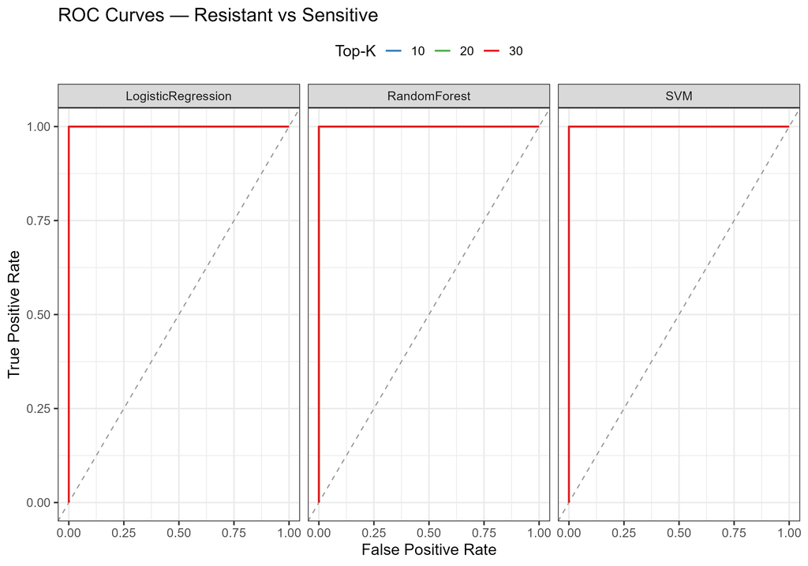

## 6.5 ROC Curves (External Validation)

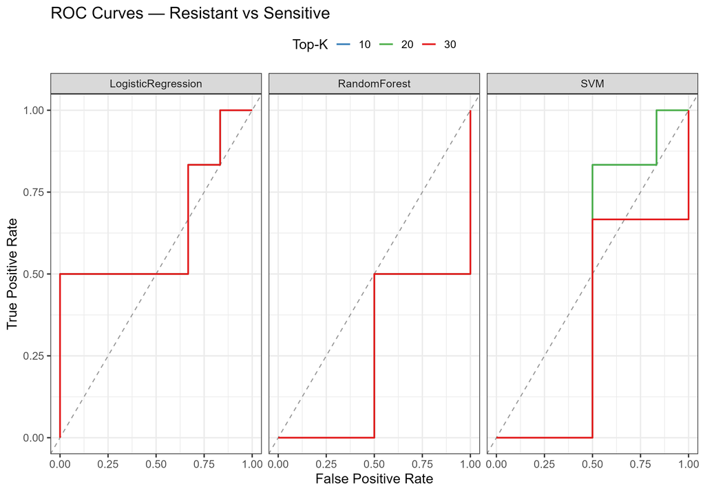

## 6.6 Confusion Matrices (LOOCV)

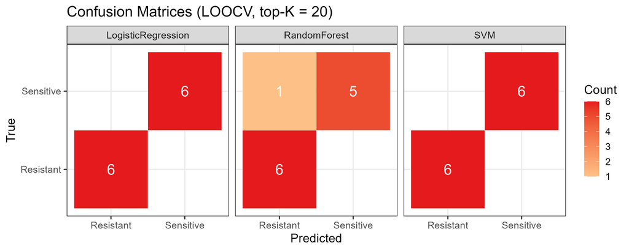

## 6.7 Feature Importance

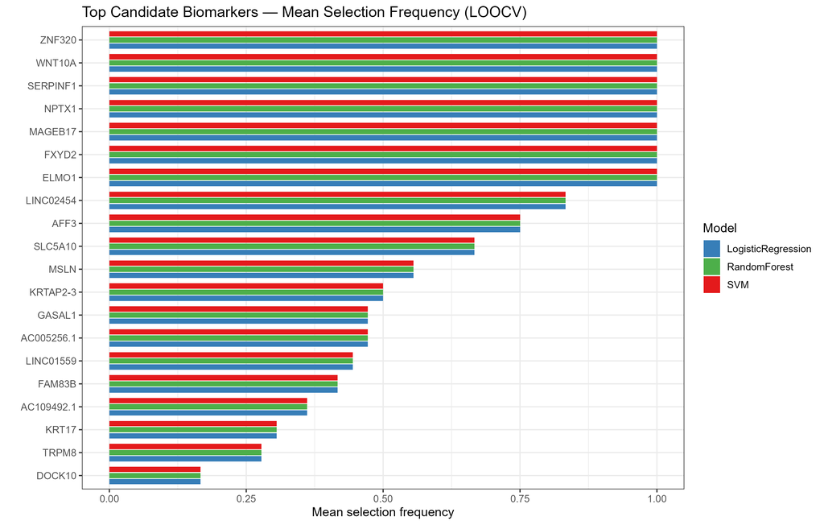

## 6.8 Candidate Biomarker Panel

[output not shown]

## 6.9 Interpretation & Caveats

1. LOOCV accuracy/AUC reflects within-study discrimination and is expected to be optimistic relative to true generalization.
2. The **external validation** is the more stringent test: training on 6 samples of one cell line and predicting the other. Results should be interpreted as exploratory given the small n.
3. Feature/gene selection for the ML models was performed strictly *inside* each training fold to prevent label leakage; the initial 418-gene candidate space itself derives from the DESeq2 cross-dataset validation step.
4. Different cell-line backgrounds (SKOV-3 vs OVCAR5) may inflate within-CV separability; cross-dataset consistency of the top biomarkers partially mitigates this.

# 7 Key Findings

## 7.1 Summary

1. **Dataset 1 (SKOV-3/GSE303889):** 5212 DEGs identified (2983 up, 2229 down)
2. **Dataset 2 (OVCAR5/GSE283381):** 2572 DEGs identified (912 up, 1660 down)
3. **Shared DEGs:** 913 genes are differentially expressed in both datasets (198 up, 220 down)
4. **Spearman correlation of log₂FC:** -0.037 (low correlation — expected given different cell line backgrounds and resistance mechanisms)

# 8 Literature Validation & Biological Interpretation

## 8.1 EMT (Epithelial-Mesenchymal Transition) — Central Theme

Our data shows a classic EMT signature in cisplatin-resistant cells, strongly supported by published literature:

| Our Finding | Literature Support |
| --- | --- |
| **CDH1 ↓** (E-cadherin) | Hallmark of EMT in cisplatin-resistant OC (Wani et al., *Sci Rep* 2025). CDH1 promoter hypermethylation confirmed in A2780cis cells (Ghosh et al., *Sci Rep* 2022). |
| **EPCAM ↓** | Downregulated alongside CDH1 during EMT in resistant variants (Galle et al.). EPCAM loss predicts chemoresistance (Gao et al., *Genes Dis* 2021). |
| **COL1A1/COL5A2/COL6A1/2 ↑** | Collagen genes are key ECM components upregulated in resistant OC. COL1A1 drives resistance through “ECM-receptor interaction” and “focal adhesion” KEGG pathways (Li et al., *Front Oncol* 2021). |
| **MMP14/MMP1 ↑** | Matrix metalloproteinases remodel ECM to facilitate invasion and drug resistance (Wani et al., *Sci Rep* 2025). |
| **TOP GO terms: ECM organization, cell-substrate adhesion** | Consistent with multiple OC resistance RNA-seq studies showing ECM remodeling as a core resistance mechanism. |

## 8.2 Inflammatory Signaling — IL1A/IL1B Axis

[output not shown]

## 8.3 NDRG1 — Validated Resistance Biomarker

[output not shown]

## 8.4 KYNU — Kynurenine Pathway in Immune Evasion

[output not shown]

## 8.5 SERPINE1 — Plasminogen Activator Inhibitor

[output not shown]

## 8.6 Pathway Convergence

Our KEGG enrichment identified pathways that converge on resistance mechanisms:

| Pathway | Role in Resistance | Key Genes from Our Data |
| --- | --- | --- |
| **PI3K-Akt signaling** | Promotes survival, inhibits apoptosis | FGFR2/4, PDGFRA, ERBB2/3/4, ITGAs |
| **Focal adhesion** | ECM-integrin-cytoskeletal axis drives EMT | COL1A1, ITGA2, VAV2, PTEN |
| **MAPK signaling** | Proliferation and drug efflux | EGFR, RAF1, MAPK1/3 |
| **Integrin signaling** | Activates Wnt/β-catenin for EMT | ITGAs, COL1A1, FN1 |
| **Cadherin signaling** | Cell adhesion loss during EMT | CDH1↓, CDH4, CDH6 |

## 8.7 Proposed Mechanistic Model

```
Cisplatin Exposure
       ↓
  DNA Damage → Chronic Inflammation (IL1A/IL1B ↑, KYNU ↑)
       ↓                        ↓
  Apoptosis Evasion         Immune Evasion
  (DAPK1 ↓, BCL2 ↑)       (KYNU/AhR axis)
       ↓                        ↓
  ECM Remodeling (COL1A1/5A2/6A1 ↑, MMP14 ↑)
       ↓
  Integrin Activation (ITGA2 ↑, Focal Adhesion)
       ↓
  Wnt/β-catenin → EMT (CDH1 ↓, EPCAM ↓)
       ↓
  Drug Efflux + Stemness → CISPLATIN RESISTANCE
```

## 8.8 Conclusions

These findings collectively define a **core cisplatin resistance transcriptomic signature** with potential applications in biomarker development and therapeutic target identification.

# 9 Output Files

| File | Description |
| --- | --- |
| `results/dataset1/DEG_table_full.csv` | All genes with DESeq2 stats (GSE303889) |
| `results/dataset1/DEGs_significant.csv` | Significant DEGs (FDR<0.05, \|log₂FC\|>1) |
| `results/dataset1/volcano_plot.png` | Volcano plot |
| `results/dataset1/heatmap_top_DEGs.png` | Heatmap of top 50 DEGs |
| `results/dataset1/MA_plot.png` | MA plot |
| `results/dataset2/...` | Same files for GSE283381 |
| `results/comparison/overlapping_DEGs.csv` | Shared DEGs between datasets |
| `results/comparison/venn_diagram.png` | Venn diagram |
| `results/comparison/lfc_correlation.png` | log₂FC correlation plot |
| `results/enrichment/*.csv` | GO and KEGG enrichment tables |
| `results/enrichment/*.png` | GO and KEGG dot plots |
| `results/ml/expression_matrix.csv` | 12-sample × gene ML feature matrix (log2 CPM+1) |
| `results/ml/ml_metrics_summary.csv` | Model performance per model / top-K / validation |
| `results/ml/predictions_LOOCV.csv` | LOOCV held-out predictions |
| `results/ml/predictions_external.csv` | Leave-one-dataset-out predictions |
| `results/ml/ROC_LOOCV.png` / `ROC_external.png` | ROC curves |
| `results/ml/confusion_LOOCV.png` | Confusion matrix heatmaps |
| `results/ml/feature_importance.csv` / `.png` | Feature selection frequencies |
| `results/ml/biomarker_panel.csv` | Top-ranked candidate biomarker panel |